# Long-Term Effects of Speed Processing Training on Older Adults

Wenxuan Zhu, Eric Wang

November 07, 2023

Abstract

Analyzing the impact of cognitive training on older adults has been a long-debated topic. Leveraging the longitudinal data from the ACTIVE study (Giuli et al. 2016), this study investigates the influence of speed-processing training on participants. Utilizing a robust Generalized Estimating Equations (GEE) model, we have identified statistically significant improvements in speed processing among adults who received speed training compared to those who did not. Furthermore, the data revealed that the improvement in speed processing was further enhanced when participants received additional random follow-up booster cognitive training, in contrast to individuals who solely underwent speed training without booster sessions.

## Introduction

The worldwide increase in the elderly population has heightened the significance of research on mitigating cognitive decline through non-pharmacological methods. Within this realm of study, The Advanced Cognitive Training for Independent and Vital Elderly (ACTIVE) study has emerged as a pivotal investigation (Tennstedt and Unverzagt 2013). Starting in the late 1990s, the ACTIVE study embarked on a quest to address a central inquiry: can cognitive function in older people be enhanced and sustained through tailored training interventions? This randomized controlled trial encompassed 2,832 participants aged 65 and above and examined the effects of three distinct cognitive training programs, targeting memory, reasoning, and processing speed. In this report, we provide an overview of the long-term impact, mainly focusing on the effects of speed training on older adults, utilizing a longitudinal data analysis model, specifically the Generalized Estimating Equations (GEE) framework.

## Research Question

The speed of cognitive processing significantly declines with age, impacting various aspects of daily life, including driving, hazard recognition, and other time-sensitive tasks (Giuli et al. 2016). This decline raises concerns about the overall quality of life for older adults. Given this context, we aim to understand how cognitive training, including potential boosters, baseline processing speed, and subsequent speed or cognitive assessments, influences the evolution of processing speed over time. We consider various speed measurement tasks, such as complex reaction time (CRT), timed instrumental activities of daily living (TIADL) tasks, and activities of daily living timing (ADLT) to provide a comprehensive analysis (Rebok et al. 2014). By addressing this research question, we contribute valuable insights into enhancing the cognitive well-being and quality of life for the elderly population.

## Method

To assess the effectiveness of cognitive training on adults, this report relies on data directly from the ACTIVE study. We conducted a data cleaning process, including variable mutation, column combination, removing outliers, etc., to perform the following on longitudinal data analysis. The whole population includes 2802 people whose average age is 73.63276 with a mean speed baseline of 938.0526. Since we aim to focus on the long-run impact of the training, we filter the population to those who participated at least once in the study from year three. 1934 people remained, with an average age of 72.92554 and an average speed of 890.1282.

| Group | Participants | Mean.Age | Mean.SpeedBase |
| --- | --- | --- | --- |
| Adult when after Year 3 | 1934 | 72.92554 | 890.1282 |
| Whole Population | 2802 | 73.63276 | 938.0526 |

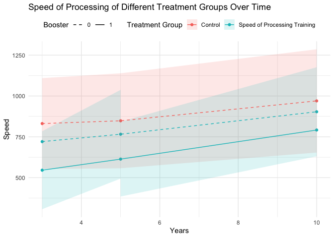

To answer the our research question, we chose the Generalized Estimating Equations (GEE) model, well-suited for correlated observational data in studies like ACTIVE, where measurements often show continuity over time. The “ar1” correlated structure in GEE assumes correlations between a data point and the one immediately preceding it, with the strength of this correlation weakening over time intervals. Also, compared to ordinary generalized linear models (GLM), GEE has significant advantages. GLM can’t handle correlations between observations, while GEE is designed for such clustered data (LIANG and ZEGER 1986). Moreover, GEE provides robust standard errors, ensuring accurate estimates even with incorrect correlation matrix specifications.

## Data cleaning & Final Model

```r
mod <- df_cleaned %>%
  drop_na(Speed, Years, INTGRP, ageOld, ADLT_group, BOOSTER, IMMRAW, CRT, TIADL, SpeedBase, BOOSTER) %>%
  geeM::geem(Speed ~ Years * (INTGRP == "Speed of Processing Training") + (INTGRP == "Speed of Processing Training") : BOOSTER + ageOld + (ADLT_group == "ADLT3+") + CRT + TIADL + SpeedBase,
             data = ., id = AID, corstr = 'ar1')
mod %>% summary()
```

```
##                                                       Estimates Model SE
## (Intercept)                                            150.3000 15.08000
## Years                                                   20.5200  1.17900
## INTGRP == "Speed of Processing Training"TRUE          -106.7000 15.84000
## ageOld                                                   8.2890  0.70270
## ADLT_group == "ADLT3+"TRUE                              60.8800 22.12000
## CRT                                                     40.3100  2.23000
## TIADL                                                   80.7400  5.46700
## SpeedBase                                                0.4375  0.01423
## Years:INTGRP == "Speed of Processing Training"TRUE       4.6690  2.13300
## INTGRP == "Speed of Processing Training"FALSE:BOOSTER   -0.0324  8.01300
## INTGRP == "Speed of Processing Training"TRUE:BOOSTER  -143.4000 13.35000
##                                                       Robust SE      wald
## (Intercept)                                            20.16000  7.455000
## Years                                                   1.39700 14.690000
## INTGRP == "Speed of Processing Training"TRUE           15.55000 -6.867000
## ageOld                                                  0.84030  9.863000
## ADLT_group == "ADLT3+"TRUE                             29.72000  2.048000
## CRT                                                     3.08200 13.080000
## TIADL                                                   7.22000 11.180000
## SpeedBase                                               0.02385 18.340000
## Years:INTGRP == "Speed of Processing Training"TRUE      2.19100  2.131000
## INTGRP == "Speed of Processing Training"FALSE:BOOSTER   8.05300 -0.004024
## INTGRP == "Speed of Processing Training"TRUE:BOOSTER   14.54000 -9.863000
##                                                             p
## (Intercept)                                           0.00000
## Years                                                 0.00000
## INTGRP == "Speed of Processing Training"TRUE          0.00000
## ageOld                                                0.00000
## ADLT_group == "ADLT3+"TRUE                            0.04053
## CRT                                                   0.00000
## TIADL                                                 0.00000
## SpeedBase                                             0.00000
## Years:INTGRP == "Speed of Processing Training"TRUE    0.03311
## INTGRP == "Speed of Processing Training"FALSE:BOOSTER 0.99680
## INTGRP == "Speed of Processing Training"TRUE:BOOSTER  0.00000
##
##  Estimated Correlation Parameter:  0.3625
##  Correlation Structure:  ar1
##  Est. Scale Parameter:  33080
##
##  Number of GEE iterations: 7
##  Number of Clusters:  1897    Maximum Cluster Size:  3
##  Number of observations with nonzero weight:  4074
```

We can represent the information in the table with the following functions for a more straightforward view,
$$\begin{aligned}
& \quad \; E(\text{Speed}\;|\; \text{Years, SpeedTraining, BOOSTER,
ageOld, ADLT3+, CRT, TIADL, SpeedBase}) \\
& = \beta_0 + \beta_1\text{Years} + \beta_21_{\text{SpeedTraining}}
+
\beta_3\text{ageOld} +\beta_41_{\text{ADLT3+}}+\beta_5\text{CRT} +
\beta_6\text{TIADL}+ \beta_7\text{SpeedBase}
+ \beta_8\text{Years:}1_{\text{SpeedTraining}} + \\
& \quad \beta_91_{\text{SpeedTraining=FALSE}}:1_\text{BOOSTER} +
\beta_{10}1_{\text{SpeedTraining=TRUE}}:1_\text{BOOSTER}
\end{aligned}$$

## Conclusions

One limitation of our model is that we prioritize simplicity, assuming a general linear relationship between predictors and the outcome. While we created numerous visualizations and carefully narrowed our research question to ensure that each variable exhibits a general linear relationship with the outcome speed, we could potentially enhance the model’s accuracy by incorporating splines to capture small curvatures. We would also appreciate consulting with an expert to refine the variable selection process and ensure the predictors in the model align with a psychiatric perspective. Nonetheless, this model effectively reflects the study’s outcome, providing valuable insights into the factors influencing processing speed in older adults and offering a solid foundation for further research in this field.

## Acknowledgements

We really appreciate our instructor [Brianna Heggeseth](https://bcheggeseth.github.io/) for providing this fantastic course. :)

## References

“Activities of Daily Living.” n.d. https://www.ncbi.nlm.nih.gov/books/NBK470404/.

Giuli, C., R. Papa, F. Lattanzio, and D. Postacchini. 2016. “The Effects of Cognitive Training for Elderly: Results from My Mind Project.” *Rejuvenation Res* 19 (6): 485–94.

“Instrumental Activity of Daily Living.” n.d. https://www.ncbi.nlm.nih.gov/books/NBK553126/.

LIANG, KUNG-YEE, and SCOTT L. ZEGER. 1986. “Longitudinal data analysis using generalized linear models.” *Biometrika* 73 (1): 13–22. https://doi.org/10.1093/biomet/73.1.13.

Rebok, G. W., K. Ball, L. T. Guey, R. N. Jones, H. Y. Kim, J. W. King, M. Marsiske, et al. 2014. “Ten-year effects of the advanced cognitive training for independent and vital elderly cognitive training trial on cognition and everyday functioning in older adults.” *J Am Geriatr Soc* 62 (1): 16–24.

Tennstedt, S. L., and F. W. Unverzagt. 2013. “The ACTIVE study: study overview and major findings.” *J Aging Health* 25 (8 Suppl): 3S–20S.